# AR、MA 与 ARMA 模型识别

下面的辅助函数分别整理ADF检验的$p$值、ACF/PACF数值、参数估计与Ljung–Box检验结果，并统一绘制诊断图和预测图。函数代码作为实验的一部分完整展示，便于读者直接复现计算。

```r
adf_result_table <- function(x, series_name) {
  test <- tseries::adf.test(as.numeric(na.omit(x)))
  data.frame(
    Series = series_name,
    LagOrder = unname(test$parameter),
    PValue = unname(test$p.value),
    row.names = NULL
  )
}

correlation_table <- function(x, lag_max = 10L) {
  data.frame(
    Lag = seq_len(lag_max),
    ACF = as.numeric(acf(x, lag.max = lag_max, plot = FALSE)$acf)[-1],
    PACF = as.numeric(pacf(x, lag.max = lag_max, plot = FALSE)$acf),
    Approximate95PercentBound = 1.96 / sqrt(length(x)),
    row.names = NULL
  )
}

coefficient_table <- function(model) {
  standard_errors <- sqrt(diag(model$var.coef))
  z_statistics <- coef(model) / standard_errors
  data.frame(
    Term = names(coef(model)),
    Estimate = unname(coef(model)),
    StandardError = unname(standard_errors),
    PValue = unname(2 * pnorm(-abs(z_statistics))),
    row.names = NULL
  )
}

ljung_box_table <- function(model, lag, fitdf) {
  test <- Box.test(
    na.omit(residuals(model)),
    lag = lag,
    type = "Ljung-Box",
    fitdf = fitdf
  )
  data.frame(
    Lag = lag,
    Statistic = unname(test$statistic),
    DegreesOfFreedom = unname(test$parameter),
    PValue = unname(test$p.value),
    row.names = NULL
  )
}

forecast_table <- function(prediction) {
  data.frame(
    Horizon = seq_along(prediction$pred),
    PointForecast = as.numeric(prediction$pred),
    Lower95 = as.numeric(prediction$pred - 1.96 * prediction$se),
    Upper95 = as.numeric(prediction$pred + 1.96 * prediction$se),
    row.names = NULL
  )
}

plot_acf_pacf <- function(x, series_name) {
  old_par <- par(mfrow = c(1, 2), mar = c(4, 4, 3, 1))
  acf(
    as.numeric(x),
    lag.max = 20,
    col = colour_main,
    main = paste("ACF:", series_name)
  )
  pacf(
    as.numeric(x),
    lag.max = 20,
    col = colour_smooth,
    main = paste("PACF:", series_name)
  )
  par(old_par)
}

plot_residuals <- function(model, model_name) {
  model_residuals <- na.omit(residuals(model))
  old_par <- par(mfrow = c(1, 2), mar = c(4, 4, 3, 1))
  plot(
    model_residuals,
    type = "l",
    lwd = 1.2,
    col = colour_main,
    main = paste(model_name, "Residuals"),
    xlab = "Time",
    ylab = "Residual"
  )
  abline(h = 0, lty = 2, col = "grey45")
  acf(
    as.numeric(model_residuals),
    lag.max = 20,
    col = colour_smooth,
    main = paste("Residual ACF:", model_name)
  )
  par(old_par)
}

plot_forecast <- function(observed, prediction, title, y_label) {
  point_forecast <- prediction$pred
  lower <- point_forecast - 1.96 * prediction$se
  upper <- point_forecast + 1.96 * prediction$se

  plot(
    observed,
    type = "l",
    lwd = 1.4,
    col = colour_main,
    xlim = range(c(time(observed), time(point_forecast))),
    ylim = range(c(observed, lower, upper), na.rm = TRUE),
    main = title,
    xlab = "Time",
    ylab = y_label
  )
  polygon(
    c(time(point_forecast), rev(time(point_forecast))),
    c(lower, rev(upper)),
    border = NA,
    col = grDevices::adjustcolor(colour_smooth, alpha.f = 0.22)
  )
  lines(point_forecast, lwd = 1.6, col = colour_smooth)
  legend(
    "topleft",
    legend = c("Observed", "Forecast", "95% interval"),
    col = c(colour_main, colour_smooth, NA),
    lty = c(1, 1, NA),
    lwd = c(1.4, 1.6, NA),
    fill = c(
      NA,
      NA,
      grDevices::adjustcolor(colour_smooth, alpha.f = 0.22)
    ),
    border = NA,
    bty = "n"
  )
}
```

本实验用三个彼此独立的真实时间序列，完成从原始数据、平稳性判断、ACF与PACF识别，到模型拟合、残差诊断和预测的完整过程。重点是根据样本相关图提出一个有统计依据的低阶模型，而不是自动搜索模型或比较信息准则。

三个实验使用统一的识别逻辑：AR模型的ACF通常逐渐衰减而PACF近似截尾；MA模型的ACF近似截尾而PACF逐渐衰减；ARMA模型的ACF和PACF通常都不在某个很低的阶数后突然消失。样本相关图不会完全复制理论图形，因而应结合相邻滞后的整体形态，而不能根据某一根偶然越过置信界限的竖线机械判断。

平稳性辅助判断采用`tseries::adf.test()`。该实现以“序列具有单位根”为原假设、以“序列平稳”为备择假设，在检验回归中包含常数项和线性趋势项，默认滞后阶数为$\lfloor(n-1)^{1/3}\rfloor$。下面直接报告$p$值，并与5%显著性水平比较：$p<0.05$时拒绝单位根原假设。ADF检验只作为时间序列图和ACF之外的辅助证据。

## 实验一：AR模型

### 原始序列与平稳性

R自带的`lh`数据记录一名女性血样中黄体生成素的浓度，共连续观测48次，相邻观测间隔10分钟。时间坐标表示观测次序，而不是年份。

```r
ar_series <- datasets::lh

data.frame(
  Series = "lh",
  Observations = length(ar_series),
  FirstObservation = start(ar_series)[1],
  LastObservation = end(ar_series)[1],
  SamplingIntervalMinutes = 10
)
```

```
  Series Observations FirstObservation LastObservation SamplingIntervalMinutes
1     lh           48                1              48                      10
```

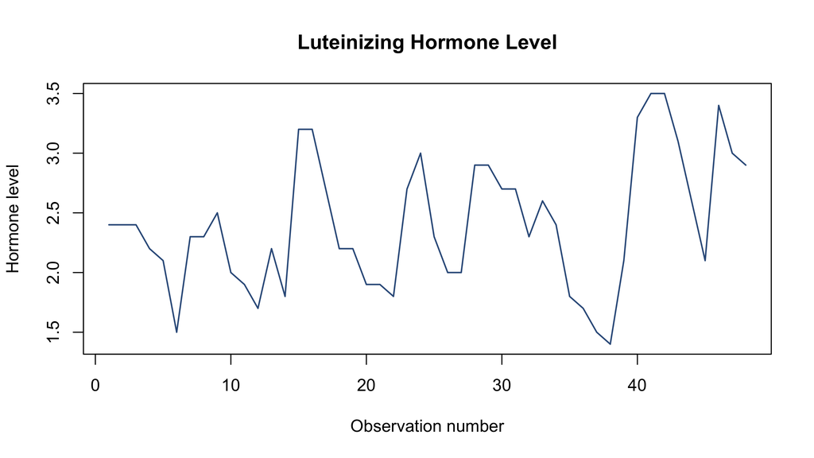

```r
plot(
  ar_series,
  type = "l",
  lwd = 1.4,
  col = colour_main,
  main = "Luteinizing Hormone Level",
  xlab = "Observation number",
  ylab = "Hormone level"
)
```

序列在1.4至3.5之间上下波动，没有持续趋势或随时间扩大的波动幅度。ADF检验得到$p=0.0462$，在5%水平拒绝单位根原假设，不过这一结果接近$0.05$的判断界限。结合时间序列图，没有必要再作差分；原序列直接作为平稳工作序列。

```r
adf_result_table(ar_series, "lh")
```

```
  Series LagOrder   PValue
1     lh        3 0.046242
```

### ACF、PACF与阶数判断

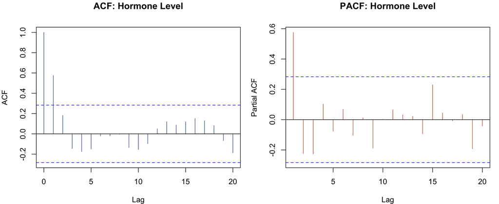

```r
plot_acf_pacf(ar_series, "Hormone Level")
```

```r
correlation_table(ar_series, lag_max = 10L)
```

```
   Lag        ACF      PACF Approximate95PercentBound
1    1  0.5755245  0.575524                    0.2829
2    2  0.1818182 -0.223410                    0.2829
3    3 -0.1447552 -0.226940                    0.2829
4    4 -0.1748252  0.102768                    0.2829
5    5 -0.1496503 -0.075934                    0.2829
6    6 -0.0209790  0.067558                    0.2829
7    7 -0.0202797 -0.104170                    0.2829
8    8 -0.0041958  0.012014                    0.2829
9    9 -0.1356643 -0.187687                    0.2829
10  10 -0.1538462  0.002551                    0.2829
```

### 模型拟合

```r
ar_model <- arima(
  ar_series,
  order = c(1, 0, 0),
  include.mean = TRUE,
  method = "ML"
)

coefficient_table(ar_model)
```

```
       Term Estimate StandardError     PValue
1       ar1  0.57394       0.11614 7.7414e-07
2 intercept  2.41326       0.14662 7.1301e-61
```

```r
data.frame(InnovationVariance = ar_model$sigma2)
```

```
  InnovationVariance
1            0.19749
```

AR系数估计为$0.5739$，标准误为$0.1161$，近似双侧检验得到$p<0.001$，说明一阶线性依赖十分明确。均值参数估计为$2.4133$，其$p<0.001$。`arima()`输出的`intercept`是平稳序列的均值参数，而不是非中心化方程中的常数项；估计模型应写为

$$X_t-2.4133=0.5739(X_{t-1}-2.4133)+\varepsilon_t,
\qquad \widehat{\sigma}^2_{\varepsilon}=0.1975.$$

### 残差诊断

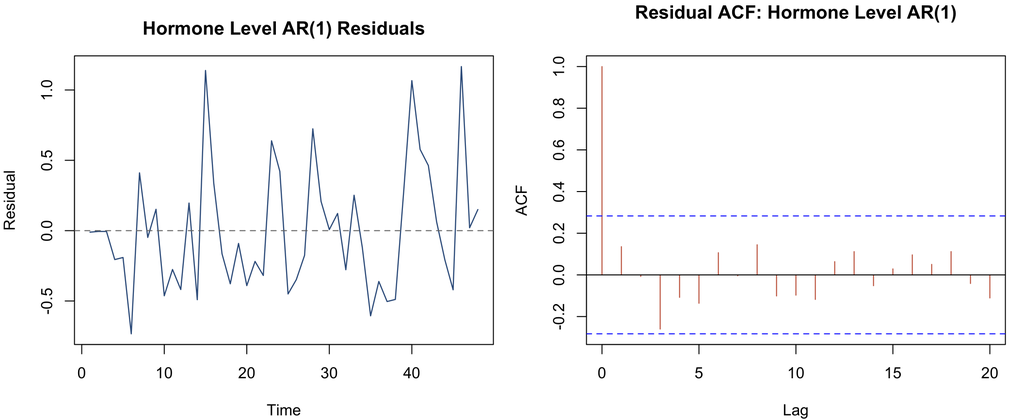

```r
plot_residuals(ar_model, "Hormone Level AR(1)")
```

```r
ljung_box_table(ar_model, lag = 10L, fitdf = 1L)
```

```
  Lag Statistic DegreesOfFreedom  PValue
1  10    9.3564                9 0.40505
```

残差围绕零波动，前20阶残差ACF全部位于约$\pm0.2829$的置信界限内。10阶Ljung–Box统计量为$9.3564$，自由度为9，$p=0.4050$，没有证据拒绝残差无自相关的原假设。因此，AR(1)已经提取了该序列中主要的线性时间依赖；这里的“近似白噪声”仅指没有发现剩余线性自相关，并不等同于证明残差彼此独立。

### 向前预测

```r
ar_prediction <- predict(ar_model, n.ahead = 8L)
forecast_table(ar_prediction)
```

```
  Horizon PointForecast Lower95 Upper95
1       1        2.6926  1.8216  3.5636
2       2        2.5736  1.5693  3.5779
3       3        2.5053  1.4608  3.5498
4       4        2.4661  1.4087  3.5234
5       5        2.4436  1.3820  3.5052
6       6        2.4307  1.3677  3.4936
7       7        2.4232  1.3598  3.4867
8       8        2.4190  1.3554  3.4826
```

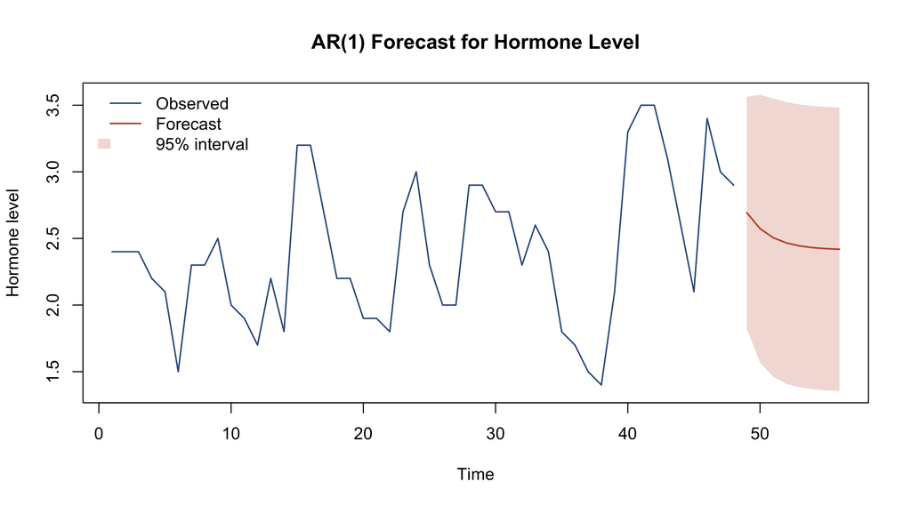

```r
plot_forecast(
  ar_series,
  ar_prediction,
  "AR(1) Forecast for Hormone Level",
  "Hormone level"
)
```

点预测从$2.6926$逐步回到长期均值$2.4133$附近，这是平稳AR(1)多步预测的典型形态；随着预测步长增加，预测区间先扩张，然后逐渐接近长期预测不确定性。

## 实验二：MA模型

### 原始序列与一阶差分

R自带的`Nile`数据记录1871年至1970年阿斯旺的尼罗河年流量，单位为$10^8\ \mathrm{m}^3$。原始图在约1898年前后出现明显的水平变化，均值稳定性值得怀疑。

```r
ma_series <- datasets::Nile
ma_working <- diff(ma_series)

data.frame(
  Series = "Nile",
  Observations = length(ma_series),
  FirstYear = start(ma_series)[1],
  LastYear = end(ma_series)[1],
  Unit = "10^8 cubic metres"
)
```

```
  Series Observations FirstYear LastYear              Unit
1   Nile          100      1871     1970 10^8 cubic metres
```

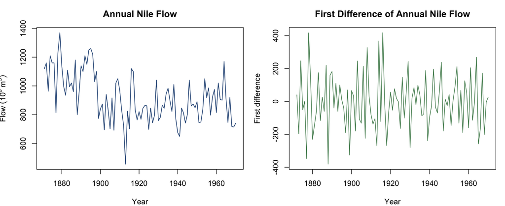

```r
old_par <- par(mfrow = c(1, 2), mar = c(4, 4, 3, 1))
plot(
  ma_series,
  type = "l",
  lwd = 1.4,
  col = colour_main,
  main = "Annual Nile Flow",
  xlab = "Year",
  ylab = expression(Flow ~ (10^8 ~ m^3))
)
plot(
  ma_working,
  type = "l",
  lwd = 1.2,
  col = colour_accent,
  main = "First Difference of Annual Nile Flow",
  xlab = "Year",
  ylab = "First difference"
)
```

```r
par(old_par)
```

原序列ADF检验得到$p=0.0642$，在5%水平不能拒绝单位根原假设。作一次普通一阶差分后，序列围绕零上下波动，没有继续差分的图形理由；差分序列的ADF检验输出$p=0.0100$，并提示真实$p$值小于该数值。因而可以拒绝单位根原假设，后续对$W_t=Y_t-Y_{t-1}$进行相关结构识别。

```r
rbind(
  adf_result_table(ma_series, "Nile level"),
  adf_result_table(ma_working, "First difference")
)
```

```
            Series LagOrder   PValue
1       Nile level        4 0.064195
2 First difference        4 0.010000
```

### ACF、PACF与阶数判断

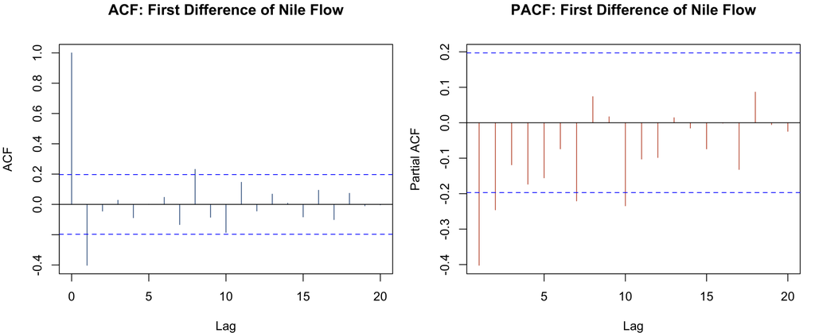

```r
plot_acf_pacf(ma_working, "First Difference of Nile Flow")
```

```r
correlation_table(ma_working, lag_max = 10L)
```

```
   Lag         ACF      PACF Approximate95PercentBound
1    1 -0.40204263 -0.402043                   0.19699
2    2 -0.04427462 -0.245613                   0.19699
3    3  0.02740458 -0.118706                   0.19699
4    4 -0.08789743 -0.173308                   0.19699
5    5  0.00050262 -0.155406                   0.19699
6    6  0.04652927 -0.073677                   0.19699
7    7 -0.13322828 -0.220527                   0.19699
8    8  0.23116331  0.073627                   0.19699
9    9 -0.08493644  0.016780                   0.19699
10  10 -0.18486616 -0.234254                   0.19699
```

差分序列ACF在第1阶为$-0.4020$，明显越过约$\pm0.1970$的置信界限；第2阶起大部分相关已经接近零。第8阶的$0.2312$是一个孤立的样本尖峰，并没有形成连续衰减结构。与此相对，PACF从$-0.4020$、$-0.2456$开始，随后以较小的负相关总体向零衰减，表现为拖尾。因而，这里将ACF解释为近似一阶截尾，并为差分序列选择MA(1)模型；对原始流量而言，这就是无漂移的ARIMA(0,1,1)模型。

### 模型拟合

```r
ma_model <- arima(
  ma_series,
  order = c(0, 1, 1),
  include.mean = FALSE,
  method = "ML"
)

coefficient_table(ma_model)
```

```
  Term Estimate StandardError           PValue
1  ma1 -0.73294       0.11432 0.00000000014431
```

```r
data.frame(InnovationVariance = ma_model$sigma2)
```

```
  InnovationVariance
1              20600
```

MA系数估计为$-0.7329$，标准误为$0.1143$，近似双侧检验得到$p<0.001$。工作序列的估计方程为

$$W_t=\varepsilon_t-0.7329\varepsilon_{t-1},
\qquad W_t=Y_t-Y_{t-1},
\qquad \widehat{\sigma}^2_{\varepsilon}=20599.9.$$

### 残差诊断

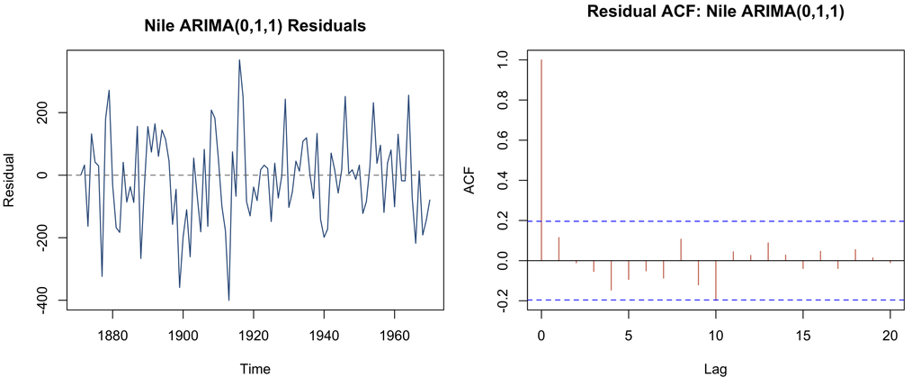

```r
plot_residuals(ma_model, "Nile ARIMA(0,1,1)")
```

```r
ljung_box_table(ma_model, lag = 10L, fitdf = 1L)
```

```
  Lag Statistic DegreesOfFreedom  PValue
1  10    13.387                9 0.14585
```

残差ACF没有持续的拖尾，第10阶相关$-0.1978$仅略微越过约$\pm0.1960$的界限。10阶Ljung–Box统计量为$13.3873$，自由度为9，$p=0.1459$，整体上没有证据拒绝无自相关原假设。综合判断，ARIMA(0,1,1)已经提取了主要线性依赖；孤立的边界尖峰提醒我们，“近似白噪声”是有限样本下的判断，而不是所有样本相关恰好为零。

### 向前预测

```r
ma_prediction <- predict(ma_model, n.ahead = 8L)
forecast_table(ma_prediction)
```

```
  Horizon PointForecast Lower95 Upper95
1       1        798.37  517.05  1079.7
2       2        798.37  507.20  1089.5
3       3        798.37  497.66  1099.1
4       4        798.37  488.42  1108.3
5       5        798.37  479.44  1117.3
6       6        798.37  470.71  1126.0
7       7        798.37  462.21  1134.5
8       8        798.37  453.92  1142.8
```

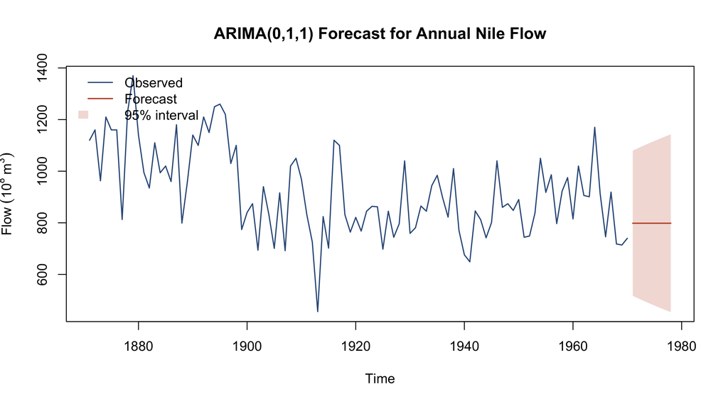

```r
plot_forecast(
  ma_series,
  ma_prediction,
  "ARIMA(0,1,1) Forecast for Annual Nile Flow",
  expression(Flow ~ (10^8 ~ m^3))
)
```

无漂移ARIMA(0,1,1)的8个点预测均为$798.367$，而预测区间随步长逐渐变宽。点预测保持不变并不表示未来流量没有波动；它表示在模型给定的信息下，未来创新的条件均值为零，而累积的不确定性仍在增加。

## 实验三：ARMA模型

### 原始序列与平稳性

`fpp3::us_change`记录美国消费、收入、生产、储蓄和失业率等经济变量的季度百分比变动。本实验使用1970年第1季度至2019年第2季度的失业率变动序列，共198个观测。这里分析的是“失业率的季度变动”，而不是失业率水平本身。

```r
unemployment_data <- as.data.frame(fpp3::us_change)
quarter_label <- as.character(unemployment_data$Quarter[1])
start_year <- as.integer(substr(quarter_label, 1L, 4L))
start_quarter <- as.integer(sub(".*Q", "", quarter_label))
arma_series <- ts(
  unemployment_data$Unemployment,
  start = c(start_year, start_quarter),
  frequency = 4
)
arma_working <- arma_series

data.frame(
  Series = "Quarterly change in US unemployment",
  Observations = length(arma_series),
  FirstQuarter = "1970 Q1",
  LastQuarter = "2019 Q2"
)
```

```
                               Series Observations FirstQuarter LastQuarter
1 Quarterly change in US unemployment          198      1970 Q1     2019 Q2
```

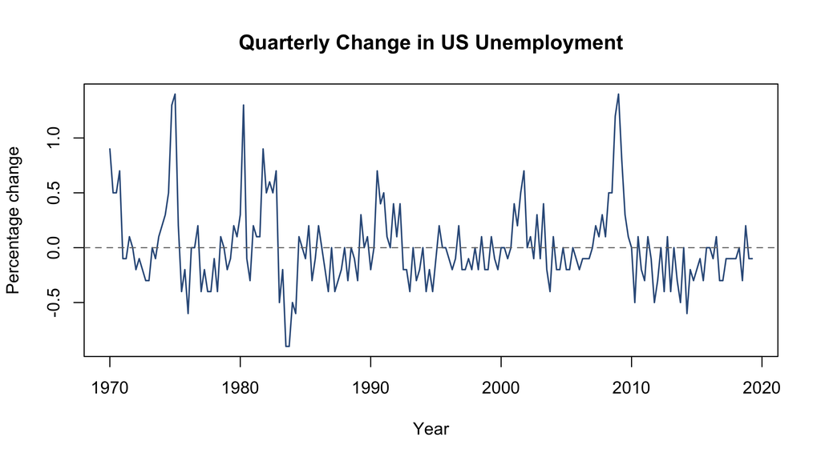

```r
plot(
  arma_series,
  type = "l",
  lwd = 1.4,
  col = colour_main,
  main = "Quarterly Change in US Unemployment",
  xlab = "Year",
  ylab = "Percentage change"
)
abline(h = 0, lty = 2, col = "grey45")
```

序列大部分时间围绕零上下波动，没有持续趋势，也没有需要季节差分的稳定季度周期；少数经济冲击时期出现较大的正负变动。ADF检验输出$p=0.0100$，并提示真实$p$值小于该数值，因此在5%水平拒绝单位根原假设。原序列已经适合作为平稳工作序列，不作额外差分或去趋势。

```r
adf_result_table(arma_series, "US unemployment change")
```

```
                  Series LagOrder PValue
1 US unemployment change        5   0.01
```

### ACF、PACF与混合结构

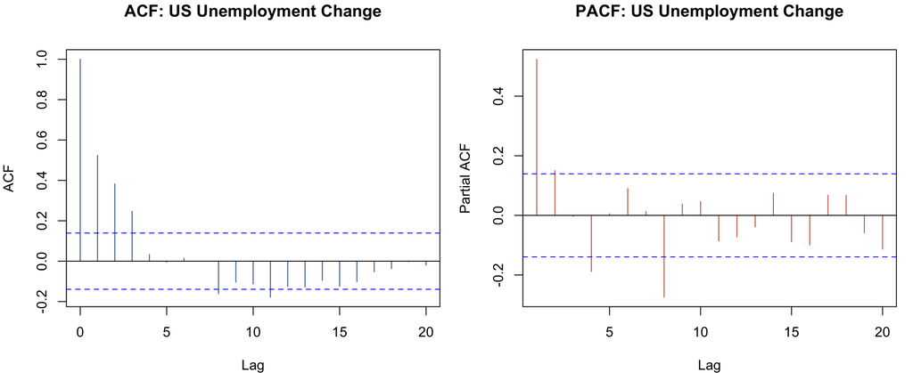

```r
plot_acf_pacf(arma_working, "US Unemployment Change")
```

```r
correlation_table(arma_working, lag_max = 20L)
```

```
   Lag         ACF       PACF Approximate95PercentBound
1    1  0.52372878  0.5237288                   0.13929
2    2  0.38341180  0.1503634                   0.13929
3    3  0.24686847 -0.0035125                   0.13929
4    4  0.03281128 -0.1883304                   0.13929
5    5 -0.00481512  0.0056000                   0.13929
6    6  0.01474097  0.0900630                   0.13929
7    7 -0.00030809  0.0131158                   0.13929
8    8 -0.16058403 -0.2744015                   0.13929
9    9 -0.10416163  0.0380855                   0.13929
10  10 -0.11320628  0.0465084                   0.13929
11  11 -0.17831235 -0.0861485                   0.13929
12  12 -0.12564840 -0.0726362                   0.13929
13  13 -0.12829722 -0.0388179                   0.13929
14  14 -0.09556564  0.0747686                   0.13929
15  15 -0.12491507 -0.0881683                   0.13929
16  16 -0.10197295 -0.0995464                   0.13929
17  17 -0.05268364  0.0679308                   0.13929
18  18 -0.03725462  0.0672445                   0.13929
19  19 -0.00263431 -0.0590087                   0.13929
20  20 -0.02027515 -0.1133737                   0.13929
```

ACF前3阶依次为$0.5237$、$0.3834$和$0.2469$，先逐步衰减而不是在第1阶突然截尾；随后出现一段接近零的相关，又在第8至16阶形成较小的负相关尾部。PACF前两阶为$0.5237$和$0.1504$，第4阶和第8阶分别为$-0.1883$和$-0.2744$，其余多为较小的正负相关。两幅图都没有呈现纯AR或纯MA模型那种整齐、低阶的截尾，而是带有逐渐减弱和零星波动的拖尾形态。因此先考虑同时包含一阶AR和一阶MA项的最简混合模型ARMA(1,1)。

为了检验这一图形判断，下面只检查两个最直接的纯模型候选AR(1)和MA(1)是否留下明显相关。这是对ACF/PACF解释的针对性核验，不是枚举模型或按信息准则选阶。

```r
arma_ar1 <- arima(
  arma_working,
  order = c(1, 0, 0),
  include.mean = TRUE,
  method = "ML"
)
arma_ma1 <- arima(
  arma_working,
  order = c(0, 0, 1),
  include.mean = TRUE,
  method = "ML"
)

rbind(
  AR1 = ljung_box_table(arma_ar1, lag = 20L, fitdf = 1L),
  MA1 = ljung_box_table(arma_ma1, lag = 20L, fitdf = 1L)
)
```

```
    Lag Statistic DegreesOfFreedom     PValue
AR1  20    30.309               19 0.04799336
MA1  20    49.541               19 0.00015305
```

AR(1)残差的20阶Ljung–Box检验得到$Q=30.3092$、$p=0.0480$，在5%水平刚好拒绝无自相关原假设；MA(1)残差得到$Q=49.5413$、$p=0.00015$，明确留下了线性自相关。两个最简单的纯模型都没有充分解释相关结构，这支持在低阶模型中同时保留AR项和MA项。

### 模型拟合

```r
arma_model <- arima(
  arma_working,
  order = c(1, 0, 1),
  include.mean = TRUE,
  method = "ML"
)

coefficient_table(arma_model)
```

```
       Term   Estimate StandardError     PValue
1       ar1  0.6977231      0.081986 1.7352e-17
2       ma1 -0.2221954      0.103057 3.1080e-02
3 intercept  0.0081231      0.055650 8.8395e-01
```

```r
data.frame(InnovationVariance = arma_model$sigma2)
```

```
  InnovationVariance
1           0.094321
```

AR系数估计为$0.6977$，标准误为$0.0820$，近似双侧检验的$p<0.001$；MA系数估计为$-0.2222$，标准误为$0.1031$，$p=0.0311$。因此AR项和MA项都提供了可辨认的线性信息。`intercept`给出的平稳序列均值估计为$0.0081$，标准误为$0.0557$，$p=0.8839$，与序列围绕零波动的图形一致。以$\mu=0.0081$表示均值，估计模型为

$$X_t-\mu=0.6977(X_{t-1}-\mu)+\varepsilon_t
-0.2222\varepsilon_{t-1},
\qquad \widehat{\sigma}^2_{\varepsilon}=0.0943.$$

### 残差诊断

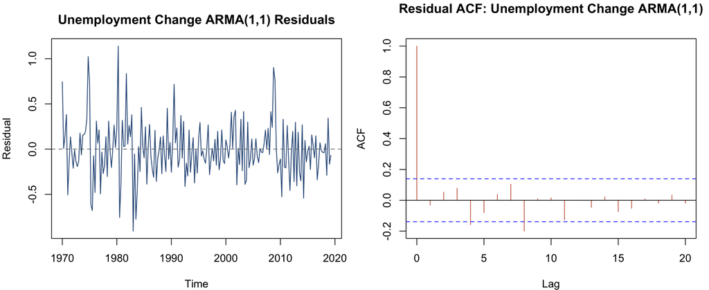

```r
plot_residuals(arma_model, "Unemployment Change ARMA(1,1)")
```

```r
ljung_box_table(arma_model, lag = 20L, fitdf = 2L)
```

```
  Lag Statistic DegreesOfFreedom  PValue
1  20    25.509               18 0.11152
```

残差大体围绕零波动，前20阶残差ACF不再表现出连续衰减；第4阶和第8阶分别为$-0.1578$和$-0.1993$，越过约$\pm0.1393$的置信界限，但属于相隔较远的孤立尖峰。20阶Ljung–Box统计量为$25.5094$，自由度为18，$p=0.1115$，整体上没有证据拒绝残差无自相关的原假设。与AR(1)和MA(1)的结果相比，ARMA(1,1)已经较好地提取主要线性依赖。这里仍不能据此断言残差独立、正态或同方差，因为Ljung–Box检验只针对一组残差自相关的联合显著性。

### 向前预测

```r
arma_prediction <- predict(arma_model, n.ahead = 8L)
forecast_table(arma_prediction)
```

```
  Horizon PointForecast  Lower95 Upper95
1       1    -0.0518647 -0.65382 0.55009
2       2    -0.0337318 -0.70028 0.63281
3       3    -0.0210800 -0.71690 0.67474
4       4    -0.0122526 -0.72189 0.69739
5       5    -0.0060935 -0.72236 0.71017
6       6    -0.0017961 -0.72127 0.71768
7       7     0.0012022 -0.71983 0.72223
8       8     0.0032942 -0.71849 0.72508
```

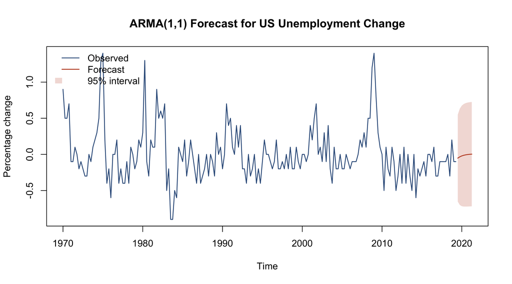

```r
plot_forecast(
  arma_series,
  arma_prediction,
  "ARMA(1,1) Forecast for US Unemployment Change",
  "Percentage change"
)
```

未来8个季度的点预测从$-0.0519$逐步回到接近零的长期均值，第8步为$0.0033$。95%预测区间逐渐稳定在约$[-0.72,0.73]$。这正是平稳ARMA模型的典型多步预测：当前冲击的影响逐步衰减，点预测回归长期均值，预测不确定性则接近过程的长期水平。

## 三个实验的对照

| 实验 | 平稳化处理 | 工作序列ADF $p$值 | ACF形态 | PACF形态 | 最终模型 | 检验滞后阶数 | Ljung–Box $p$值 |
| --- | --- | --- | --- | --- | --- | --- | --- |
| 黄体生成素浓度 | 不变换 | 0.0462 | 快速拖尾 | 1阶后截尾 | AR(1) | 10 | 0.4050 |
| 尼罗河年流量 | 一阶差分 | 0.0100（报告下限） | 近似1阶截尾 | 总体拖尾 | ARIMA(0,1,1) | 10 | 0.1459 |
| 美国失业率季度变动 | 不变换 | 0.0100（报告下限） | 逐步衰减并有负相关尾部 | 无清晰低阶截尾 | ARMA(1,1) | 20 | 0.1115 |

三个实验说明，ACF与PACF的“截尾”和“拖尾”是模型识别线索而不是机械规则。面对实际数据，应先用时间序列图和简单单位根检验确定工作序列，再根据ACF/PACF提出低阶模型，最后由残差图、残差ACF和Ljung–Box检验检查是否仍有系统性的线性相关。只有这三个环节彼此一致时，一个简单ARIMA模型才构成完整、可解释的分析结果。